# ExtraaLearn Project

## Context

The EdTech industry has been surging in the past decade immensely, and according to a forecast, the Online Education market would be worth $286.62bn by 2023 with a compound annual growth rate (CAGR) of 10.26% from 2018 to 2023. The modern era of online education has enforced a lot in its growth and expansion beyond any limit. Due to having many dominant features like ease of information sharing, personalized learning experience, transparency of assessment, etc, it is now preferable to traditional education.

In the present scenario due to the Covid-19, the online education sector has witnessed rapid growth and is attracting a lot of new customers. Due to this rapid growth, many new companies have emerged in this industry. With the availability and ease of use of digital marketing resources, companies can reach out to a wider audience with their offerings. The customers who show interest in these offerings are termed as leads. There are various sources of obtaining leads for Edtech companies, like

- The customer interacts with the marketing front on social media or other online platforms.
- The customer browses the website/app and downloads the brochure
- The customer connects through emails for more information.

The company then nurtures these leads and tries to convert them to paid customers. For this, the representative from the organization connects with the lead on call or through email to share further details.

## Objective

ExtraaLearn is an initial stage startup that offers programs on cutting-edge technologies to students and professionals to help them upskill/reskill. With a large number of leads being generated on a regular basis, one of the issues faced by ExtraaLearn is to identify which of the leads are more likely to convert so that they can allocate resources accordingly. As a data scientist at ExtraaLearn, the goal is to:

- Analyze and build an ML model to help identify which leads are more likely to convert to paid customers,
- Find the factors driving the lead conversion process
- Create a profile of the leads which are likely to convert

## Data Description

The data contains the different attributes of leads and their interaction details with ExtraaLearn. The detailed data dictionary is given below.

**Data Dictionary**

- ID: ID of the lead
- age: Age of the lead
- current_occupation: Current occupation of the lead. Values include 'Professional','Unemployed',and 'Student'
- first_interaction: How did the lead first interacted with ExtraaLearn. Values include 'Website', 'Mobile App'
- profile_completed: What percentage of profile has been filled by the lead on the website/mobile app. Values include Low - (0-50%), Medium - (50-75%), High (75-100%)
- website_visits: How many times has a lead visited the website
- time_spent_on_website: Total time spent on the website
- page_views_per_visit: Average number of pages on the website viewed during the visits.
- last_activity: Last interaction between the lead and ExtraaLearn.
  - Email Activity: Seeking for details about program through email, Representative shared information with lead like brochure of program , etc
  - Phone Activity: Had a Phone Conversation with representative, Had conversation over SMS with representative, etc
  - Website Activity: Interacted on live chat with representative, Updated profile on website, etc
- print_media_type1: Flag indicating whether the lead had seen the ad of ExtraaLearn in the Newspaper.
- print_media_type2: Flag indicating whether the lead had seen the ad of ExtraaLearn in the Magazine.
- digital_media: Flag indicating whether the lead had seen the ad of ExtraaLearn on the digital platforms.
- educational_channels: Flag indicating whether the lead had heard about ExtraaLearn in the education channels like online forums, discussion threads, educational websites, etc.
- referral: Flag indicating whether the lead had heard about ExtraaLearn through reference.
- status: Flag indicating whether the lead was converted to a paid customer or not.

## Importing necessary libraries and data

```python
# Importing essential libraries for data manipulation, visualization, statistical analysis, and model building
import pandas as pd
import numpy as np
import seaborn as sns
import matplotlib.pyplot as plt
import scipy.stats as stats
from sklearn.model_selection import train_test_split, GridSearchCV
from sklearn.tree import DecisionTreeClassifier
from sklearn.metrics import accuracy_score
from sklearn.model_selection import cross_val_score
import matplotlib.pyplot as plt
from sklearn.tree import plot_tree
from sklearn.ensemble import RandomForestClassifier
from sklearn.metrics import accuracy_score, classification_report, confusion_matrix
```

```python
# Suppress FutureWarnings
import warnings
warnings.simplefilter(action='ignore', category=FutureWarning)
warnings.simplefilter(action='ignore', category=UserWarning)
```

## Data Overview

- Observations
- Sanity checks

### Step 1: Loading the Dataset

First, we load the dataset from a CSV file into a pandas dataframe.

```python
# Reading the dataset from a CSV file into a pandas DataFrame
df = pd.read_csv('ExtraaLearn.csv')
```

### Step 2: Inspecting the Data

We check the first few rows of the dataset

```python
# Display the first 5 rows of the DataFrame to get a quick overview of the data
df.head()
```

|  | ID | age | current_occupation | first_interaction | profile_completed | website_visits | time_spent_on_website | page_views_per_visit | last_activity | print_media_type1 | print_media_type2 | digital_media | educational_channels | referral | status |
| --- | --- | --- | --- | --- | --- | --- | --- | --- | --- | --- | --- | --- | --- | --- | --- |
| 0 | EXT001 | 57 | Unemployed | Website | High | 7 | 1639 | 1.861 | Website Activity | Yes | No | Yes | No | No | 1 |
| 1 | EXT002 | 56 | Professional | Mobile App | Medium | 2 | 83 | 0.320 | Website Activity | No | No | No | Yes | No | 0 |
| 2 | EXT003 | 52 | Professional | Website | Medium | 3 | 330 | 0.074 | Website Activity | No | No | Yes | No | No | 0 |
| 3 | EXT004 | 53 | Unemployed | Website | High | 4 | 464 | 2.057 | Website Activity | No | No | No | No | No | 1 |
| 4 | EXT005 | 23 | Student | Website | High | 4 | 600 | 16.914 | Email Activity | No | No | No | No | No | 0 |

### Step 3: Random Sample Inspection

To get a quick look at a small, random subset of the data, we randomly select 5 rows from the dataset

```python
# Randomly select 5 rows from the DataFrame for quick inspection
df.sample(5)
```

|  | ID | age | current_occupation | first_interaction | profile_completed | website_visits | time_spent_on_website | page_views_per_visit | last_activity | print_media_type1 | print_media_type2 | digital_media | educational_channels | referral | status |
| --- | --- | --- | --- | --- | --- | --- | --- | --- | --- | --- | --- | --- | --- | --- | --- |
| 4494 | EXT4495 | 40 | Professional | Mobile App | High | 5 | 71 | 4.123 | Email Activity | No | No | No | No | No | 0 |
| 2599 | EXT2600 | 32 | Unemployed | Website | Medium | 2 | 968 | 0.235 | Website Activity | No | No | No | No | No | 0 |
| 2743 | EXT2744 | 20 | Student | Website | Medium | 2 | 336 | 3.610 | Email Activity | No | No | No | No | No | 0 |
| 2516 | EXT2517 | 53 | Professional | Website | Medium | 2 | 366 | 0.260 | Website Activity | Yes | No | No | No | No | 0 |
| 2277 | EXT2278 | 57 | Professional | Website | Medium | 4 | 714 | 2.107 | Phone Activity | Yes | No | No | No | No | 0 |

### Step 4: Inspecting Data Dimensions and Summary Statistics

- First we check the **number of rows and columns** in the dataset
- We use `describe()` to generate summary statistics for the numerical columns in the dataset

```python
# Get the number of rows and columns in the DataFrame
df.shape
```

```
(4612, 15)
```

```python
# Generate summary statistics for numerical columns in the DataFrame
df.describe()
```

|  | age | website_visits | time_spent_on_website | page_views_per_visit | status |
| --- | --- | --- | --- | --- | --- |
| count | 4612.000000 | 4612.000000 | 4612.000000 | 4612.000000 | 4612.000000 |
| mean | 46.201214 | 3.566782 | 724.011275 | 3.026126 | 0.298569 |
| std | 13.161454 | 2.829134 | 743.828683 | 1.968125 | 0.457680 |
| min | 18.000000 | 0.000000 | 0.000000 | 0.000000 | 0.000000 |
| 25% | 36.000000 | 2.000000 | 148.750000 | 2.077750 | 0.000000 |
| 50% | 51.000000 | 3.000000 | 376.000000 | 2.792000 | 0.000000 |
| 75% | 57.000000 | 5.000000 | 1336.750000 | 3.756250 | 1.000000 |
| max | 63.000000 | 30.000000 | 2537.000000 | 18.434000 | 1.000000 |

- Then we get summary Statistics for Categorical Columns

```python
# Generate summary statistics for categorical (object) columns in the DataFrame
df.describe(include='object')
```

|  | ID | current_occupation | first_interaction | profile_completed | last_activity | print_media_type1 | print_media_type2 | digital_media | educational_channels | referral |
| --- | --- | --- | --- | --- | --- | --- | --- | --- | --- | --- |
| count | 4612 | 4612 | 4612 | 4612 | 4612 | 4612 | 4612 | 4612 | 4612 | 4612 |
| unique | 4612 | 3 | 2 | 3 | 3 | 2 | 2 | 2 | 2 | 2 |
| top | EXT001 | Professional | Website | High | Email Activity | No | No | No | No | No |
| freq | 1 | 2616 | 2542 | 2264 | 2278 | 4115 | 4379 | 4085 | 3907 | 4519 |

- **Data Overview**: We use `info()` to get a concise summary of the DataFrame

```python
# Display concise summary of the DataFrame, including data types and non-null counts
df.info()
```

```
<class 'pandas.core.frame.DataFrame'>
RangeIndex: 4612 entries, 0 to 4611
Data columns (total 15 columns):
 #   Column                 Non-Null Count  Dtype
---  ------                 --------------  -----
 0   ID                     4612 non-null   object
 1   age                    4612 non-null   int64
 2   current_occupation     4612 non-null   object
 3   first_interaction      4612 non-null   object
 4   profile_completed      4612 non-null   object
 5   website_visits         4612 non-null   int64
 6   time_spent_on_website  4612 non-null   int64
 7   page_views_per_visit   4612 non-null   float64
 8   last_activity          4612 non-null   object
 9   print_media_type1      4612 non-null   object
 10  print_media_type2      4612 non-null   object
 11  digital_media          4612 non-null   object
 12  educational_channels   4612 non-null   object
 13  referral               4612 non-null   object
 14  status                 4612 non-null   int64
dtypes: float64(1), int64(4), object(10)
memory usage: 540.6+ KB
```

- **Identifying Duplicates**: We use `duplicated()` to check for and display any **duplicate rows** in the dataset, which might need to be cleaned.

```python
# Select and display rows that are duplicates in the DataFrame
df[df.duplicated()]
```

|  | ID | age | current_occupation | first_interaction | profile_completed | website_visits | time_spent_on_website | page_views_per_visit | last_activity | print_media_type1 | print_media_type2 | digital_media | educational_channels | referral | status |
| --- | --- | --- | --- | --- | --- | --- | --- | --- | --- | --- | --- | --- | --- | --- | --- |

## **Exploratory Data Analysis (EDA)**

Exploratory Data Analysis (EDA) is a crucial step in any data-driven project. Before building a model, it is essential to explore and understand the dataset to uncover patterns, relationships, and potential insights. A structured analysis will help in making informed decisions about feature selection and model development.

To guide the analysis, the following key questions have been considered:

1. **Impact of Occupation on Lead Conversion**
   - Leads may have different expectations based on their current occupation. Understanding how occupation influences conversion rates can help in refining targeting strategies.
2. **Effect of First Interaction Channel on Conversion**
   - The initial point of interaction could significantly impact the lead’s decision. Analyzing whether the first interaction channel affects conversion can help optimize marketing efforts.
3. **Effectiveness of Different Interaction Methods**
   - The company engages with prospects through multiple communication channels, such as email, phone, and website interactions. Identifying which method yields the highest conversion rates can enhance engagement strategies.
4. **Conversion Rates Across Lead Acquisition Channels**
   - Leads originate from various sources, including print media, digital platforms, and referrals. Evaluating which channel contributes the most to successful conversions can inform future marketing investments.
5. **Impact of Profile Completion on Lead Conversion**
   - Users are often required to complete their profiles before accessing additional information. Analyzing whether a higher profile completion rate correlates with higher conversions can provide insights into user behavior and engagement.

A comprehensive analysis, beyond just these questions, is conducted to extract meaningful insights from the data.

## Data Preprocessing

- Missing value treatment
- Feature engineering
- Outlier detection and treatment
- Preparing data for modeling
- Any other preprocessing steps
- **Inspecting the Data**: We display the **first 3 rows** of the DataFrame

```python
# Display the first 3 rows of the DataFrame to get a quick overview of the data
df.head(3)
```

|  | ID | age | current_occupation | first_interaction | profile_completed | website_visits | time_spent_on_website | page_views_per_visit | last_activity | print_media_type1 | print_media_type2 | digital_media | educational_channels | referral | status |
| --- | --- | --- | --- | --- | --- | --- | --- | --- | --- | --- | --- | --- | --- | --- | --- |
| 0 | EXT001 | 57 | Unemployed | Website | High | 7 | 1639 | 1.861 | Website Activity | Yes | No | Yes | No | No | 1 |
| 1 | EXT002 | 56 | Professional | Mobile App | Medium | 2 | 83 | 0.320 | Website Activity | No | No | No | Yes | No | 0 |
| 2 | EXT003 | 52 | Professional | Website | Medium | 3 | 330 | 0.074 | Website Activity | No | No | Yes | No | No | 0 |

### Exploring the Relationship Between Current Occupation and Lead Status

- **Grouping and Counting**: We group the data by `current_occupation` and then count the number of occurrences of each `status` (converted or not) within each occupation. This helps us understand how the `status` variable varies across different occupations.

```python
# Group the data by 'current_occupation' and then get the count of each 'status' within each group
df.groupby('current_occupation')['status'].value_counts()
```

```
current_occupation  status
Professional        0         1687
                    1          929
Student             0          490
                    1           65
Unemployed          0         1058
                    1          383
Name: count, dtype: int64
```

```python
df.groupby('current_occupation')['status'].value_counts('count')
```

```
current_occupation  status
Professional        0         0.644878
                    1         0.355122
Student             0         0.882883
                    1         0.117117
Unemployed          0         0.734212
                    1         0.265788
Name: proportion, dtype: float64
```

- **Visualization**:
  - We create a **count plot** to visualize how the `status` variable (0 or 1) is distributed across different `current_occupation` categories.
  - The plot includes **count labels** on top of each bar, showing the exact number of occurrences.

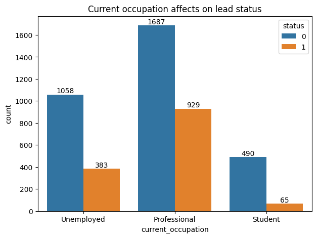

```python
# Set the figure size for the plot (7 inches wide and 5 inches tall)
plt.figure(figsize=(7, 5))
# Create a count plot showing the distribution of 'status' across different 'current_occupation'
ax = sns.countplot(data=df, x='current_occupation', hue='status')
# Loop through each container (each set of bars) and add count labels on top of the bars
for container in ax.containers:
    ax.bar_label(container, fontsize=10, color='black')
# Set the title of the plot
plt.title('Current occupation affects on lead status')
# Display the plot
plt.show()
```

- **Statistical Test**:
  - To test whether there is a significant relationship between `current_occupation` and `status`, we perform a **Chi-Square test**
  - The resulting **p-value** helps us make the decision:
    - If the **p-value** is less than 0.05, we conclude that there is a significant relationship.
    - Otherwise, we conclude that there is no significant relationship.

```python
# Create a contingency table to summarize the relationship between 'current_occupation' and 'status'
contingency_table = pd.crosstab(df['current_occupation'], df['status'])

# Perform Chi-Square test
# This tests whether there is a significant association between 'current_occupation' and 'status'
chi2, p_value, dof, expected = stats.chi2_contingency(contingency_table)

# Output the Chi-Square statistic and p-value
print(f"Chi-Square Statistic: {chi2}")
print(f"P-Value: {p_value}")

# Decision based on p-value
if p_value < 0.05:
    print("There is a significant relationship between current_occupation and status.")
else:
    print("There is no significant relationship between current_occupation and status.")
```

```
Chi-Square Statistic: 134.59904099211036
P-Value: 5.918199675434894e-30
There is a significant relationship between current_occupation and status.
```

### Analyzing the Impact of First Interaction on Lead Status

- **Grouping and Counting**: We begin by grouping the data by the `first_interaction` column and counting the number of occurrences of each `status` (converted or not) within each interaction type. This helps us understand how lead status varies across different types of first interactions (e.g., Website, Mobile App).

```python
# Group the data by 'first_interaction' and get the count of each 'status' within each group
df.groupby('first_interaction')['status'].value_counts('count')
```

```
first_interaction  status
Mobile App         0         0.894686
                   1         0.105314
Website            0         0.544060
                   1         0.455940
Name: proportion, dtype: float64
```

- **Visualization**: We create a **count plot** to visualize the distribution of `status` across various `first_interaction` categories.

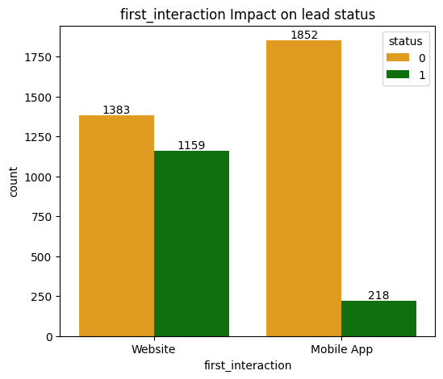

```python
# Set the figure size for the plot (6 inches wide and 5 inches tall)
plt.figure(figsize=(6, 5))
# Create a count plot showing the distribution of 'status' across 'first_interaction' categories
ax = sns.countplot(data=df, x='first_interaction', hue='status', palette=['orange', 'green'])
# Add count labels directly on the bars
for container in ax.containers:
    ax.bar_label(container, fontsize=10, color='black')
# Set the title of the plot
plt.title('first_interaction Impact on lead status')
plt.show()
```

- **Statistical Test**:
  - To test if there is a significant relationship between the `first_interaction` and `status` variables, We perform the **Chi-Square test of independence** using `chi2_contingency()` to determine whether the observed relationship is statistically significant.

```python
# Create a contingency table to summarize the relationship between 'first_interaction' and 'status'
contingency_table = pd.crosstab(df['first_interaction'], df['status'])

# Perform Chi-Square test of independence on the contingency table
chi2, p_value, dof, expected = stats.chi2_contingency(contingency_table)

# Output the Chi-Square statistic and p-value
print(f"Chi-Square Statistic: {chi2}")
print(f"P-Value: {p_value}")

# Decision based on p-value
if p_value < 0.05:
    print("There is a significant relationship between first_interaction and status.")
else:
    print("There is no significant relationship between first_interaction and status.")
```

```
Chi-Square Statistic: 668.0813826411269
P-Value: 2.611251831709229e-147
There is a significant relationship between first_interaction and status.
```

### Which way of interaction works best?

- **Percentage Calculation**:
  - We calculate the **percentage** of people who interacted through the **Website** and were converted to paid customers.

```python
# Calculate the percentage of people with Website interaction who were converted to a paid customer
df.loc[(df['first_interaction']=='Website') & (df['status']==1)]['ID'].count() / df.loc[df['first_interaction']=='Website']['ID'].count()
```

```
0.45594020456333595
```

```python
# Double check the result by manually calculating the percentage of people with Website interaction who were converted to paid customer
1159 / (1383+1159)
```

```
0.45594020456333595
```

- We calculate the **percentage** of people who interacted through the **Mobile App** and were converted to paid customers.

```python
# Calculate the percentage of people with Mobile App interaction who were converted to a paid customer
df.loc[(df['first_interaction']=='Mobile App') & (df['status']==1)]['ID'].count() / df.loc[df['first_interaction']=='Mobile App']['ID'].count()
```

```
0.10531400966183575
```

```python
# Double check the result by manually calculating the percentage of people with Mobile App interaction who were converted to paid customer
218 / (218+1852)
```

```
0.10531400966183575
```

##### The result shows that Website interaction works best in order to convert a person to a lead (paid customer)

### Which way of interaction works best?

```python
df['last_activity'].value_counts()
```

```
last_activity
Email Activity      2278
Phone Activity      1234
Website Activity    1100
Name: count, dtype: int64
```

```python
# Group the data by 'last_activity' and get the count of each 'status' within each group
df.groupby('last_activity')['status'].value_counts('count')
```

```
last_activity     status
Email Activity    0         0.696664
                  1         0.303336
Phone Activity    0         0.786872
                  1         0.213128
Website Activity  0         0.615455
                  1         0.384545
Name: proportion, dtype: float64
```

It appears that Website is not only the most effective first interaction for converting a person to a paid customer, but it also proves to be the most impactful last activity in driving lead conversion.

```python
# Create a contingency table to summarize the relationship between 'last_activity' and 'status'
contingency_table = pd.crosstab(df['last_activity'], df['status'])

# Perform the Chi-Square test of independence on the contingency table
chi2, p_value, dof, expected = stats.chi2_contingency(contingency_table)

# Output the Chi-Square statistic and p-value
print(f"Chi-Square Statistic: {chi2}")
print(f"P-Value: {p_value}")

# Decision based on p-value
if p_value < 0.05:
    print("There is a significant relationship between profile_completed and status.")
else:
    print("There is no significant relationship between profile_completed and status.")
```

```
Chi-Square Statistic: 82.08794773478009
P-Value: 1.4956453807549296e-18
There is a significant relationship between profile_completed and status.
```

Therefore, the impact of different last_activity groups on status is statistically significant.

### Analyzing the Conversion Rate for Different Channels

- **Channel List**: We begin by defining a list of channel names that we want to analyze. These channels represent different ways a lead might have interacted with the platform (e.g., print media, digital media, referral).
- **Loop Through Channels**: For each channel in the `channels` list, we first **display the value counts** which gives us the distribution of responses (e.g., 'Yes' or 'No') for each channel.

```python
# List of channel names to loop through
channels = ['print_media_type1', 'print_media_type2', 'digital_media', 'educational_channels', 'referral']
# Loop through each channel in the 'channels' list
for c in channels:
    # Display the value counts of the channel column, including NaN values
    print(df[c].value_counts(dropna=False))
    # Calculate and display the conversion rate for the current channel
    print('The conversion rate for channel:', c, 'is: ', (df.loc[(df[c]=='Yes') & (df['status']==1)]['ID'].count()) / (df.loc[df[c]=='Yes']['ID'].count()))
```

```
print_media_type1
No     4115
Yes     497
Name: count, dtype: int64
The conversion rate for channel: print_media_type1 is:  0.3199195171026157
print_media_type2
No     4379
Yes     233
Name: count, dtype: int64
The conversion rate for channel: print_media_type2 is:  0.3218884120171674
digital_media
No     4085
Yes     527
Name: count, dtype: int64
The conversion rate for channel: digital_media is:  0.3187855787476281
educational_channels
No     3907
Yes     705
Name: count, dtype: int64
The conversion rate for channel: educational_channels is:  0.2794326241134752
referral
No     4519
Yes      93
Name: count, dtype: int64
The conversion rate for channel: referral is:  0.6774193548387096
```

It appears that the referral channel has the highest lead conversion rate, with a value of 0.67.

### Analyzing the Impact of Profile Completion on Lead Status

- **Grouping and Counting**:
  - We group the data by the `profile_completed` column and count how many leads are converted (status = 1) or not (status = 0) within each profile completion category (e.g., High, Medium, Low). This helps us understand how profile completion influences lead conversion.

```python
# Group the data by 'profile_completed' and get the count of each 'status' within each group
df.groupby('profile_completed')['status'].value_counts('count')
```

```
profile_completed  status
High               0         0.582155
                   1         0.417845
Low                0         0.925234
                   1         0.074766
Medium             0         0.811245
                   1         0.188755
Name: proportion, dtype: float64
```

- **Visualization**:
  - We create a **count plot** to show the distribution of `status` across different levels of `profile_completed`.
  - **Count labels** are added to the bars to display the exact number of leads in each category.

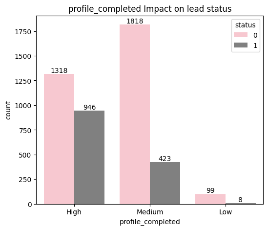

```python
# Set the figure size for the plot (6 inches wide and 5 inches tall)
plt.figure(figsize=(6, 5))
# Create a count plot showing the distribution of 'status' across 'profile_completed' categories
ax = sns.countplot(data=df, x='profile_completed', hue='status', palette=['pink', 'Gray'])
# Add count labels directly on the bars
for container in ax.containers:
    ax.bar_label(container, fontsize=10, color='black')
# Set the title of the plot
plt.title('profile_completed Impact on lead status')
plt.show()
```

The High level of profile completion appears to be the most effective in driving lead conversion compared to the other levels of profile completion.

- **Statistical Test**:
  - To determine if there is a significant relationship between `profile_completed` and `status`, we perform a **Chi-Square test of independence** on the contingency table using `chi2_contingency()`. The resulting **p-value** tells us whether the relationship between `profile_completed` and `status` is statistically significant:
    - If the **p-value** is less than 0.05, we conclude that there is a significant relationship.

```python
# Create a contingency table to summarize the relationship between 'profile_completed' and 'status'
contingency_table = pd.crosstab(df['profile_completed'], df['status'])

# Perform the Chi-Square test of independence on the contingency table
chi2, p_value, dof, expected = stats.chi2_contingency(contingency_table)

# Output the Chi-Square statistic and p-value
print(f"Chi-Square Statistic: {chi2}")
print(f"P-Value: {p_value}")

# Decision based on p-value
if p_value < 0.05:
    print("There is a significant relationship between profile_completed and status.")
else:
    print("There is no significant relationship between profile_completed and status.")
```

```
Chi-Square Statistic: 308.4293372457932
P-Value: 1.0602795584134175e-67
There is a significant relationship between profile_completed and status.
```

- **Conversion Rate Calculation**:
  - We calculate the **percentage** of people who were converted to a paid customer (status = 1) for each level of `profile_completed` (High, Medium, Low). This helps us understand how profile completion impacts the likelihood of conversion:
    - For **High profile completion**.
    - For **Medium profile completion**.
    - For **Low profile completion**.

```python
# Calculate the percentage of people with 'profile_completed' as 'High' who were converted to a paid customer
df.loc[(df['profile_completed']=='High') & (df['status']==1)]['ID'].count() / df.loc[df['profile_completed']=='High']['ID'].count()
```

```
0.4178445229681979
```

```python
# Calculate the percentage of people with 'profile_completed' as 'Medium' who were converted to a paid customer
df.loc[(df['profile_completed']=='Medium') & (df['status']==1)]['ID'].count() / df.loc[df['profile_completed']=='Medium']['ID'].count()
```

```
0.18875502008032127
```

```python
# Calculate the percentage of people with 'profile_completed' as 'Low' who were converted to a paid customer
df.loc[(df['profile_completed']=='Low') & (df['status']==1)]['ID'].count() / df.loc[df['profile_completed']=='Low']['ID'].count()
```

```
0.07476635514018691
```

#### The more details about a prospect, The more increase in chances of conversion

### Data Cleaning and Initial Exploration

- **Checking for Missing Values**:
  - We use `isna().any()` to check if there are any **missing (NaN)** values in the DataFrame for each column. This helps us identify any gaps in the data that might need to be addressed before analysis.

```python
# Check if there are any missing (NaN) values in the DataFrame for each column
df.isna().any()
```

```
ID                       False
age                      False
current_occupation       False
first_interaction        False
profile_completed        False
website_visits           False
time_spent_on_website    False
page_views_per_visit     False
last_activity            False
print_media_type1        False
print_media_type2        False
digital_media            False
educational_channels     False
referral                 False
status                   False
dtype: bool
```

### Feature engineering

- **Converting 'Yes'/'No' to 1/0**:
  - A list of channel columns is defined, including `print_media_type1`, `print_media_type2`, `digital_media`, `educational_channels`, and `referral`.
  - We loop through these columns and convert any `'Yes'` responses to `1` and `'No'` responses to `0`. This transformation makes the data numeric, which is often required for machine learning models.

```python
#  List of channel columns to process:
channels = ['print_media_type1', 'print_media_type2', 'digital_media', 'educational_channels', 'referral']
# Loop through each channel column to convert 'Yes' to 1 and 'No' to 0
for c in channels:
    df.loc[df[c]=='Yes', c] = 1
    df.loc[df[c]=='No', c] = 0
```

- **Inspecting the Data**:
  - We use `head()` to display the **first 5 rows** of the DataFrame

```python
# Display the first 5 rows of the DataFrame to get a quick overview of the data
df.head()
```

|  | ID | age | current_occupation | first_interaction | profile_completed | website_visits | time_spent_on_website | page_views_per_visit | last_activity | print_media_type1 | print_media_type2 | digital_media | educational_channels | referral | status |
| --- | --- | --- | --- | --- | --- | --- | --- | --- | --- | --- | --- | --- | --- | --- | --- |
| 0 | EXT001 | 57 | Unemployed | Website | High | 7 | 1639 | 1.861 | Website Activity | 1 | 0 | 1 | 0 | 0 | 1 |
| 1 | EXT002 | 56 | Professional | Mobile App | Medium | 2 | 83 | 0.320 | Website Activity | 0 | 0 | 0 | 1 | 0 | 0 |
| 2 | EXT003 | 52 | Professional | Website | Medium | 3 | 330 | 0.074 | Website Activity | 0 | 0 | 1 | 0 | 0 | 0 |
| 3 | EXT004 | 53 | Unemployed | Website | High | 4 | 464 | 2.057 | Website Activity | 0 | 0 | 0 | 0 | 0 | 1 |
| 4 | EXT005 | 23 | Student | Website | High | 4 | 600 | 16.914 | Email Activity | 0 | 0 | 0 | 0 | 0 | 0 |

- **Checking the Data Types of Channel Columns**:
  - We can inspect the data types of the columns in the channel list to ensure they are in the correct format for analysis.

```python
# Display concise summary of the DataFrame, including data types and non-null counts
df.info()
```

```
<class 'pandas.core.frame.DataFrame'>
RangeIndex: 4612 entries, 0 to 4611
Data columns (total 15 columns):
 #   Column                 Non-Null Count  Dtype
---  ------                 --------------  -----
 0   ID                     4612 non-null   object
 1   age                    4612 non-null   int64
 2   current_occupation     4612 non-null   object
 3   first_interaction      4612 non-null   object
 4   profile_completed      4612 non-null   object
 5   website_visits         4612 non-null   int64
 6   time_spent_on_website  4612 non-null   int64
 7   page_views_per_visit   4612 non-null   float64
 8   last_activity          4612 non-null   object
 9   print_media_type1      4612 non-null   object
 10  print_media_type2      4612 non-null   object
 11  digital_media          4612 non-null   object
 12  educational_channels   4612 non-null   object
 13  referral               4612 non-null   object
 14  status                 4612 non-null   int64
dtypes: float64(1), int64(4), object(10)
memory usage: 540.6+ KB
```

- **Converting Channel Columns from 'Object' to 'Int'**:
  - After checking the data types of the channel columns, we convert the columns in the channel list from the 'object' type to the 'int' type.

```python
# Convert specified columns to integers
channels = ['print_media_type1', 'print_media_type2', 'digital_media', 'educational_channels', 'referral']
df[channels] = df[channels].astype(int)
```

```python
# Display concise summary of the DataFrame, including data types and non-null counts
df.info()
```

```
<class 'pandas.core.frame.DataFrame'>
RangeIndex: 4612 entries, 0 to 4611
Data columns (total 15 columns):
 #   Column                 Non-Null Count  Dtype
---  ------                 --------------  -----
 0   ID                     4612 non-null   object
 1   age                    4612 non-null   int64
 2   current_occupation     4612 non-null   object
 3   first_interaction      4612 non-null   object
 4   profile_completed      4612 non-null   object
 5   website_visits         4612 non-null   int64
 6   time_spent_on_website  4612 non-null   int64
 7   page_views_per_visit   4612 non-null   float64
 8   last_activity          4612 non-null   object
 9   print_media_type1      4612 non-null   int32
 10  print_media_type2      4612 non-null   int32
 11  digital_media          4612 non-null   int32
 12  educational_channels   4612 non-null   int32
 13  referral               4612 non-null   int32
 14  status                 4612 non-null   int64
dtypes: float64(1), int32(5), int64(4), object(5)
memory usage: 450.5+ KB
```

- **Counting Unique Values**:
  - We use `value_counts(dropna=False)` to display the count of unique values in several columns:
    - **`last_activity`**: Counts how many unique values exist in the `last_activity` column, including any missing (NaN) values.
    - **`profile_completed`**: Counts the occurrences of each unique value in the `profile_completed` column, including missing values.
    - **`current_occupation`**: Displays how many different occupations are listed and includes missing values.
    - **`first_interaction`**: Counts the unique values in the `first_interaction` column and includes NaN values.

```python
# Display the count of unique values in the 'last_activity' column, including NaN values
df['last_activity'].value_counts(dropna=False)
```

```
last_activity
Email Activity      2278
Phone Activity      1234
Website Activity    1100
Name: count, dtype: int64
```

```python
# Display the count of unique values in the 'profile_completed' column, including NaN values
df['profile_completed'].value_counts(dropna=False)
```

```
profile_completed
High      2264
Medium    2241
Low        107
Name: count, dtype: int64
```

```python
# Display the count of unique values in the 'current_occupation' column, including NaN values
df['current_occupation'].value_counts(dropna=False)
```

```
current_occupation
Professional    2616
Unemployed      1441
Student          555
Name: count, dtype: int64
```

```python
# Display the count of unique values in the 'first_interaction' column, including NaN values
df['first_interaction'].value_counts(dropna=False)
```

```
first_interaction
Website       2542
Mobile App    2070
Name: count, dtype: int64
```

**Exploring the 'ID' Column**:

- We extract the **first 3 characters** from the `ID` column using `str[:3]` and count how many times each unique prefix appears. This helps identify if there are any patterns in the IDs.
- We also count how many unique `ID` values exist using `value_counts()`, which gives insight into the distribution and uniqueness of `ID`s in the dataset.

```python
# Extract the first 3 characters from the 'ID' column and count the occurrences of each unique prefix
df['ID'].str[:3].value_counts()
```

```
ID
EXT    4612
Name: count, dtype: int64
```

```python
# Display the count of unique values in the 'ID' column
df['ID'].value_counts()
```

```
ID
EXT001     1
EXT2884    1
EXT3080    1
EXT3079    1
EXT3078    1
          ..
EXT1537    1
EXT1536    1
EXT1535    1
EXT1534    1
EXT4612    1
Name: count, Length: 4612, dtype: int64
```

- The 'ID' column is not useful because the numeric part serves the same role as the index of the DataFrame, and the letter part, 'EXT', is the same for all rows. Therefore, I will drop this column.

```python
# Delete the 'ID' column from the DataFrame
del df['ID']
```

```python
# Display the first 3 rows of the DataFrame to get a quick overview of the data
df.head(3)
```

|  | age | current_occupation | first_interaction | profile_completed | website_visits | time_spent_on_website | page_views_per_visit | last_activity | print_media_type1 | print_media_type2 | digital_media | educational_channels | referral | status |
| --- | --- | --- | --- | --- | --- | --- | --- | --- | --- | --- | --- | --- | --- | --- |
| 0 | 57 | Unemployed | Website | High | 7 | 1639 | 1.861 | Website Activity | 1 | 0 | 1 | 0 | 0 | 1 |
| 1 | 56 | Professional | Mobile App | Medium | 2 | 83 | 0.320 | Website Activity | 0 | 0 | 0 | 1 | 0 | 0 |
| 2 | 52 | Professional | Website | Medium | 3 | 330 | 0.074 | Website Activity | 0 | 0 | 1 | 0 | 0 | 0 |

### Detecting Outlier and treatment: Visualizing the Distribution of Key Variables

In this section, we create **box plots** and **histograms** for different numerical variables to analyze their distributions.

- A **box plot** is created to display the distribution and identify any potential outliers in data.
- A **histogram** with a **kernel density estimate (KDE)** is then used to visualize the distribution of data and give insights into its shape.

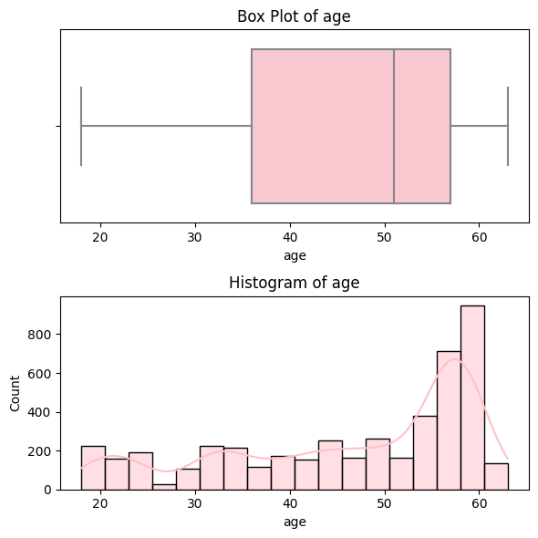

```python
# Create a figure with two rows and one column
fig, axes = plt.subplots(2, 1, figsize=(6, 6))

# Create the box plot for 'age' on the first subplot (row 1)
sns.boxplot(data=df, x='age', ax=axes[0], color = 'pink')
axes[0].set_title('Box Plot of age')

# Create the histogram for 'age' on the second subplot (row 2)
sns.histplot(data=df, x='age', kde=True, ax=axes[1], color = 'pink')
axes[1].set_title('Histogram of age')

# Adjust the layout for better spacing
plt.tight_layout()
plt.show()
```

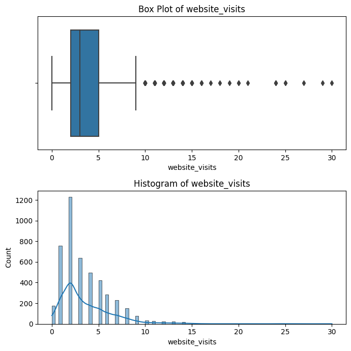

```python
# Create a figure with two rows and one column
fig, axes = plt.subplots(2, 1, figsize=(7, 7))

# Create the box plot of 'website_visits' on the first subplot (row 1)
sns.boxplot(data=df, x='website_visits', ax=axes[0])
axes[0].set_title('Box Plot of website_visits')

# Create the histogram of 'website_visits' on the second subplot (row 2)
sns.histplot(data=df, x='website_visits', kde=True, ax=axes[1])
axes[1].set_title('Histogram of website_visits')

# Adjust the layout for better spacing
plt.tight_layout()
plt.show()
```

- It seems that website_visits has lots of outliers.

```python
# Get the maximum value in the 'website_visits' column
df['website_visits'].max()
```

```
30
```

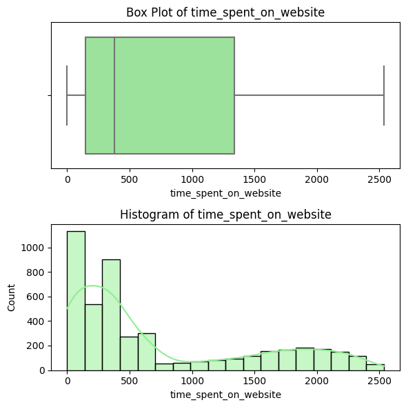

```python
# Create a figure with two rows and one column
fig, axes = plt.subplots(2, 1, figsize=(6, 6))

# Create the box plot of 'time_spent_on_website' on the first subplot (row 1)
sns.boxplot(data=df, x='time_spent_on_website', ax=axes[0], color = 'lightgreen')
axes[0].set_title('Box Plot of time_spent_on_website')

# Create the histogram of 'time_spent_on_website' on the second subplot (row 2)
sns.histplot(data=df, x='time_spent_on_website', kde=True, ax=axes[1], color = 'lightgreen')
axes[1].set_title('Histogram of time_spent_on_website')

# Adjust the layout for better spacing
plt.tight_layout()
plt.show()
```

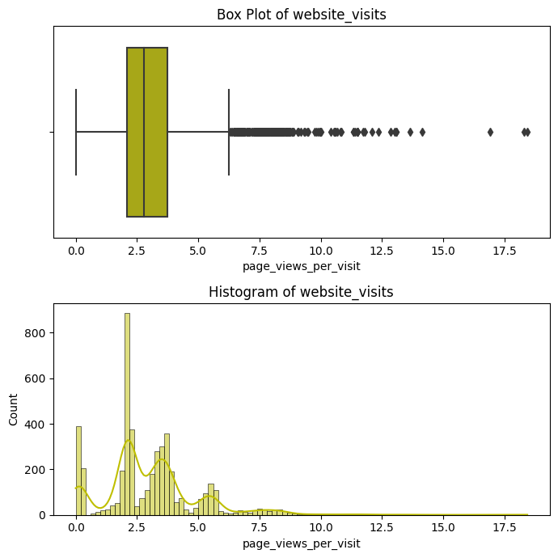

```python
# Create a figure with two rows and one column
fig, axes = plt.subplots(2, 1, figsize=(7, 7))

# Create the box plot of 'page_views_per_visit' on the first subplot (row 1)
sns.boxplot(data=df, x='page_views_per_visit', ax=axes[0], color = 'y')
axes[0].set_title('Box Plot of website_visits')

# Create the histogram of 'page_views_per_visit' on the second subplot (row 2)
sns.histplot(data=df, x='page_views_per_visit', kde=True, ax=axes[1], color = 'y')
axes[1].set_title('Histogram of website_visits')

# Adjust the layout for better spacing
plt.tight_layout()
plt.show()
```

- It seems that page_views_per_visit has lots of outliers.

```python
# Get the maximum value in the 'page_views_per_visit' column
df['page_views_per_visit'].max()
```

```
18.434
```

### Visualizing Relationships Between Multiple Numerical Variables

In this step, we create a **pairplot** to visualize the relationships between multiple numerical variables in the dataset. The selected variables are:

- `age`
- `website_visits`
- `time_spent_on_website`
- `page_views_per_visit`

The **pairplot** displays scatter plots for each pair of variables and histograms on the diagonal.

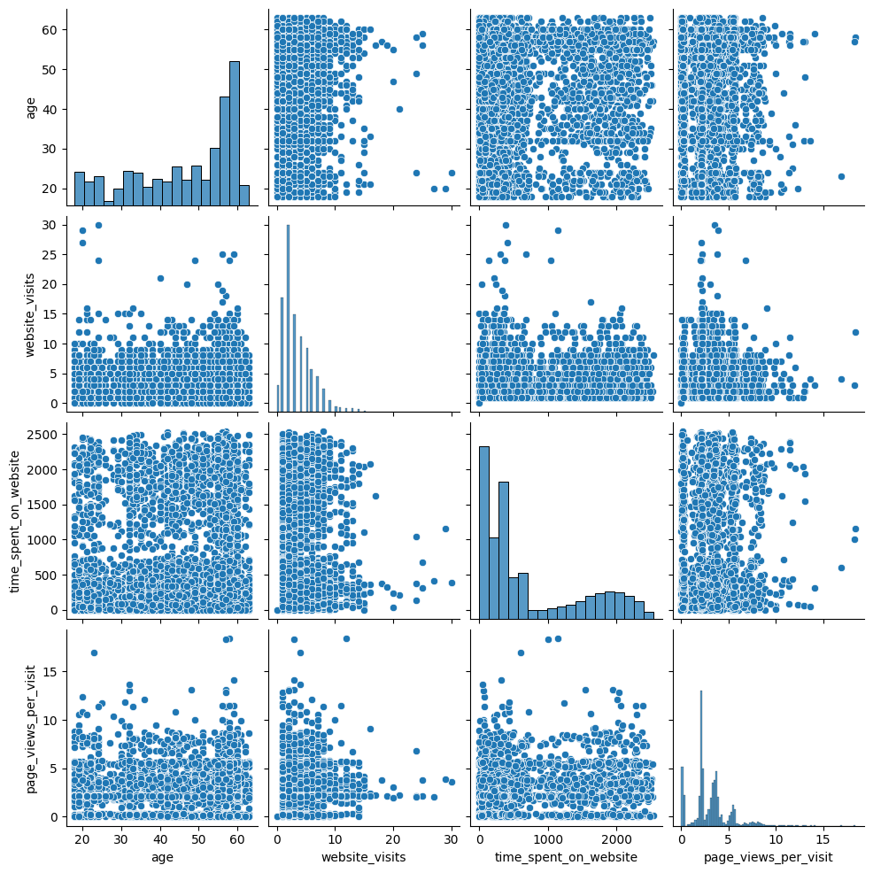

```python
# Set the figure size for the plot (7 inches wide and 7 inches tall)
plt.figure(figsize=(7,7))
# Create a pairplot to visualize the relationships between multiple numerical variables
sns.pairplot(data=df[['age', 'website_visits', 'time_spent_on_website', 'page_views_per_visit']])
```

### Analyzing Correlations Between Numerical Variables

In this step, we perform **correlation analysis** to understand the relationships between the selected numerical variables in the dataset. The variables we are analyzing are:

- `age`
- `website_visits`
- `time_spent_on_website`
- `page_views_per_visit`
- **Correlation Matrix**:
  - We generate a **correlation matrix** using the `corr()` function, which calculates the pairwise correlation coefficients between the numerical variables. This helps us identify how strongly each pair of variables is related.

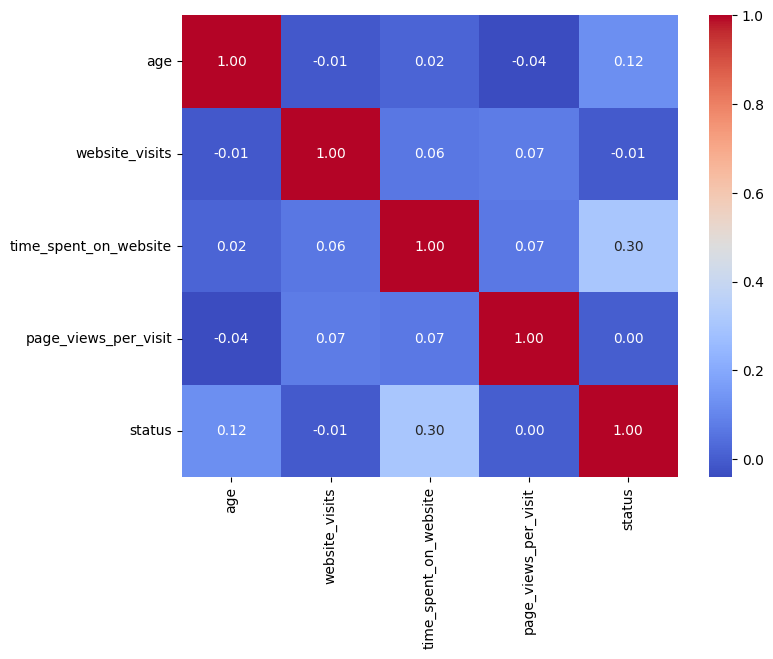

```python
# Select the numeric columns to focus on for correlation analysis
df_numeric = df[['age', 'website_visits', 'time_spent_on_website', 'page_views_per_visit',"status"]]

# Generate the correlation matrix to examine the relationships between the numeric variables
corr_matrix = df_numeric.corr()

# Set the figure size for the heatmap
plt.figure(figsize=(8, 6))

# Create a heatmap to visualize the correlation matrix
sns.heatmap(corr_matrix, annot=True, cmap='coolwarm', fmt='.2f')

plt.show()
```

- It seems that the independent variables do not show a strong correlation with each other, which is good because it suggests that multicollinearity is not an issue. However, **time_spent_on_website** stands out with a relatively higher correlation to the dependent variable **status** compared to the other features.

#### Preparing data for modeling

### Encoding Categorical Variables

In this section, we handle the categorical variables by converting them into numeric values using **dummy variables**.

- **Step 1: Select Categorical Columns**:
  - We first select the categorical columns from the dataset, which need to be converted into numerical representations.
- **Step 2: Create Dummy Variables**:
  - We use the `pd.get_dummies()` function to convert the selected categorical columns into **dummy variables** (binary columns).
- **Step 3: Merge the Dummy Variables**:
  - The new dummy variables are then merged with the original DataFrame using `pd.concat()`, adding the binary columns to the dataset.
- **Step 4: Drop the Original Categorical Columns**:
  - Finally, we drop the original categorical columns.

```python
# Step 1: Select categorical columns for dummy variable conversion
df_categorical = df[['current_occupation', 'first_interaction', 'profile_completed', 'last_activity']]

# Step 2: Create dummy variables for categorical columns
df_dummies = pd.get_dummies(df_categorical, drop_first=True, dtype=int)

# Step 3: Merge the dummy variables with the original DataFrame
df = pd.concat([df, df_dummies], axis=1)

# Step 4: Drop the original categorical columns
df.drop(columns=['current_occupation', 'first_interaction', 'profile_completed', 'last_activity'], inplace=True)
```

## EDA

- It is a good idea to explore the data once again after manipulating it.

```python
# Randomly select 6 rows from the DataFrame for quick inspection
df.sample(6)
```

|  | age | website_visits | time_spent_on_website | page_views_per_visit | print_media_type1 | print_media_type2 | digital_media | educational_channels | referral | status | current_occupation_Student | current_occupation_Unemployed | first_interaction_Website | profile_completed_Low | profile_completed_Medium | last_activity_Phone Activity | last_activity_Website Activity |
| --- | --- | --- | --- | --- | --- | --- | --- | --- | --- | --- | --- | --- | --- | --- | --- | --- | --- |
| 416 | 50 | 2 | 422 | 0.040 | 0 | 0 | 1 | 0 | 0 | 1 | 0 | 0 | 1 | 0 | 1 | 0 | 0 |
| 2255 | 56 | 2 | 55 | 2.112 | 0 | 0 | 0 | 0 | 0 | 0 | 0 | 0 | 1 | 0 | 1 | 0 | 1 |
| 3804 | 38 | 1 | 381 | 5.189 | 0 | 0 | 0 | 0 | 0 | 0 | 0 | 0 | 0 | 0 | 0 | 0 | 1 |
| 907 | 58 | 1 | 334 | 5.408 | 0 | 0 | 0 | 0 | 0 | 1 | 0 | 1 | 1 | 0 | 0 | 0 | 0 |
| 3132 | 36 | 2 | 88 | 6.484 | 0 | 0 | 0 | 0 | 0 | 1 | 0 | 1 | 1 | 0 | 0 | 0 | 0 |
| 2340 | 57 | 8 | 239 | 5.641 | 0 | 0 | 0 | 0 | 0 | 0 | 0 | 0 | 1 | 0 | 1 | 1 | 0 |

#### Decision Trees and Random Forests generally do not require feature scaling before applying these models.

## Building and Evaluating a Decision Tree model

In this section, we build a **Decision Tree** model to predict the **lead status** (`status`). The model is trained on the features and tested on a separate test set.

```python
# Separate the features (X) and target (y)
X = df.drop(columns=['status'])  # Features
y = df['status']  # Target variable

# Split the data into training and testing sets (80% train, 20% test)
X_train, X_test, y_train, y_test = train_test_split(X, y, test_size=0.2, random_state=42)
```

```
Accuracy: 0.80
Classification Report:
              precision    recall  f1-score   support

           0       0.86      0.86      0.86       649
           1       0.67      0.67      0.67       274

    accuracy                           0.80       923
   macro avg       0.77      0.77      0.77       923
weighted avg       0.80      0.80      0.80       923

Confusion Matrix:
[[560  89]
 [ 91 183]]
Feature: age, Importance: 0.1079
Feature: website_visits, Importance: 0.0605
Feature: time_spent_on_website, Importance: 0.2941
Feature: page_views_per_visit, Importance: 0.1272
Feature: print_media_type1, Importance: 0.0056
Feature: print_media_type2, Importance: 0.0064
Feature: digital_media, Importance: 0.0120
Feature: educational_channels, Importance: 0.0081
Feature: referral, Importance: 0.0064
Feature: current_occupation_Student, Importance: 0.0000
Feature: current_occupation_Unemployed, Importance: 0.0408
Feature: first_interaction_Website, Importance: 0.1464
Feature: profile_completed_Low, Importance: 0.0199
Feature: profile_completed_Medium, Importance: 0.1087
Feature: last_activity_Phone Activity, Importance: 0.0346
Feature: last_activity_Website Activity, Importance: 0.0215
```

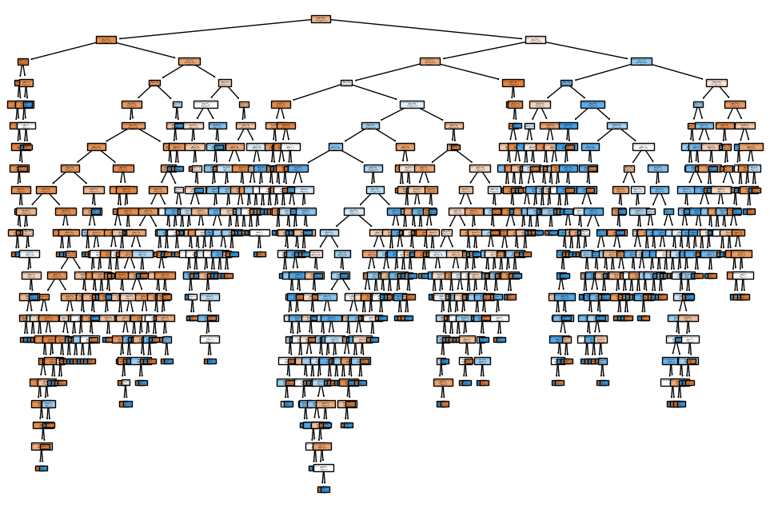

```python
# Step 1: Create the Decision Tree model using default parameters
model = DecisionTreeClassifier(random_state=42)

# Step 2: Fit the model to the training data
model.fit(X_train, y_train)

# Step 3: Make predictions on the test set
y_pred = model.predict(X_test)

# Step 4: Evaluate the model's performance (accuracy score)
accuracy = accuracy_score(y_test, y_pred)
print(f"Accuracy: {accuracy:.2f}")

# Step 5: Print the classification report
print("Classification Report:")
print(classification_report(y_test, y_pred))

# Step 6: Confusion Matrix
print("Confusion Matrix:")
print(confusion_matrix(y_test, y_pred))

# Step 7: Get the feature importances
feature_importances = model.feature_importances_

# Display the feature importances
for feature, importance in zip(X_train.columns, feature_importances):
    print(f"Feature: {feature}, Importance: {importance:.4f}")

# Step 8: Visualize the Decision Tree
plt.figure(figsize=(12, 8))
plot_tree(model, filled=True, feature_names=X.columns, class_names=['0', '1'])
plt.show()
```

After training the **Decision Tree** model and based on the feature importance values, **'time_spent_on_website'** and **'first_interaction_Website'** are the most important features in predicting whether a lead will convert to a paid customer.

## Do we need to prune the tree?

### Evaluating Model Performance on Training Data

```python
# Make predictions on the training set
y_pred_train = model.predict(X_train)
# Calculate the accuracy by comparing the predicted values with the true values
accuracy = accuracy_score(y_train, y_pred_train)
# Print the accuracy of the model on the training data, formatted to two decimal places
print(f"Accuracy: {accuracy:.2f}")
```

```
Accuracy: 1.00
```

After making predictions on the **training data**, we calculate the **accuracy** of the model. In this case, the model achieved an accuracy of **1.00** (100%) on the training set.

This unusually high accuracy suggests that the model may have **overfitted** to the training data.

To address overfitting, we should perform **grid search** to tune the hyperparameters of the model, especially focusing on the **pruning** process.

```
Cross-validation scores: [0.81571816 0.80758808 0.80894309 0.79945799 0.81953867]
Average cross-validation score: 0.81
Best parameters from Grid Search: {'criterion': 'entropy', 'max_depth': 7, 'min_samples_leaf': 1, 'min_samples_split': 2}
Test set accuracy: 0.87
Classification Report:
              precision    recall  f1-score   support

           0       0.90      0.91      0.91       649
           1       0.78      0.76      0.77       274

    accuracy                           0.87       923
   macro avg       0.84      0.83      0.84       923
weighted avg       0.86      0.87      0.86       923

Confusion Matrix:
[[592  57]
 [ 67 207]]
Feature: age, Importance: 0.0813
Feature: website_visits, Importance: 0.0158
Feature: time_spent_on_website, Importance: 0.2919
Feature: page_views_per_visit, Importance: 0.0340
Feature: print_media_type1, Importance: 0.0021
Feature: print_media_type2, Importance: 0.0021
Feature: digital_media, Importance: 0.0000
Feature: educational_channels, Importance: 0.0000
Feature: referral, Importance: 0.0077
Feature: current_occupation_Student, Importance: 0.0096
Feature: current_occupation_Unemployed, Importance: 0.0592
Feature: first_interaction_Website, Importance: 0.2180
Feature: profile_completed_Low, Importance: 0.0272
Feature: profile_completed_Medium, Importance: 0.1700
Feature: last_activity_Phone Activity, Importance: 0.0382
Feature: last_activity_Website Activity, Importance: 0.0431
```

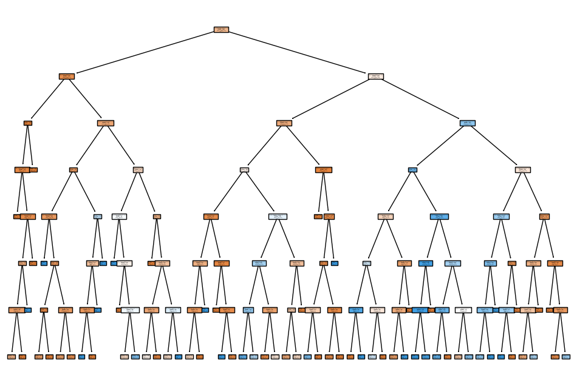

```python
# Step 1: Create the Decision Tree model
model = DecisionTreeClassifier(random_state=42)

# Step 2: Perform Cross-Validation to evaluate the model
cv_scores = cross_val_score(model, X_train, y_train, cv=5)  # 5-fold cross-validation
print(f"Cross-validation scores: {cv_scores}")
print(f"Average cross-validation score: {cv_scores.mean():.2f}")

# Step 3: Hyperparameter tuning with Grid Search
param_grid = {
    'max_depth': [3, 5, 7, 10, None],
    'min_samples_split': [2, 5, 10],
    'min_samples_leaf': [1, 2, 4],
    'criterion': ['gini', 'entropy']
}

grid_search = GridSearchCV(estimator=model, param_grid=param_grid, cv=5, scoring='accuracy', n_jobs=-1)
grid_search.fit(X_train, y_train)

# Step 4: Display the best hyperparameters found by Grid Search
print("Best parameters from Grid Search:", grid_search.best_params_)

# Step 5: Evaluate the best model on the test set
best_model = grid_search.best_estimator_
y_pred = best_model.predict(X_test)

# Step 6: Evaluate the model's performance (accuracy score)
accuracy = accuracy_score(y_test, y_pred)
print(f"Test set accuracy: {accuracy:.2f}")

# Step 7: Print the classification report
print("Classification Report:")
print(classification_report(y_test, y_pred))

# Step 8: Confusion Matrix
print("Confusion Matrix:")
print(confusion_matrix(y_test, y_pred))

# Step 9: Get the feature importances
feature_importances = best_model.feature_importances_

# Display the feature importances
for feature, importance in zip(X_train.columns, feature_importances):
    print(f"Feature: {feature}, Importance: {importance:.4f}")

# Step 10: Visualize the Decision Tree
plt.figure(figsize=(12, 8))
plot_tree(best_model, filled=True, feature_names=X.columns, class_names=['0', '1'])
plt.show()
```

After training the **Decision Tree** model and based on the feature importance values, again **'time_spent_on_website'** and **'first_interaction_Website'** are the most important features in predicting whether a lead will convert to a paid customer.

### Evaluating the Best Model Performance on the Training Data

After performing **grid search** and optimizing the model, we make predictions using the **best model** on the **training set** and calculate the accuracy.

```python
# Make predictions on the training set using the best model
y_train_pred = best_model.predict(X_train)
# Calculate the accuracy by comparing the predicted values with the true values for the training set
accuracy_train = accuracy_score(y_train, y_train_pred)
# Print the accuracy of the best model on the training data, formatted to two decimal places
print(f"Train set accuracy: {accuracy_train:.2f}")
```

```
Train set accuracy: 0.89
```

This lower accuracy (0.89) indicates that the model is no longer overfitting the training data, which suggests that the model is now **generalizing better** and is no longer overly complex.

By reducing the depth of the decision tree during the grid search, we have improved the model's ability to perform well on unseen data, addressing the overfitting issue.

## Building and Evaluating the Random Forest model

In this section, we build a **Random Forest** model to predict the **lead status** (`status`) and evaluate its performance using the test set.

```
Test set accuracy: 0.86
Classification Report:
              precision    recall  f1-score   support

           0       0.88      0.94      0.91       649
           1       0.82      0.69      0.75       274

    accuracy                           0.86       923
   macro avg       0.85      0.81      0.83       923
weighted avg       0.86      0.86      0.86       923

Confusion Matrix:
[[608  41]
 [ 85 189]]
Feature: age, Importance: 0.0813
Feature: website_visits, Importance: 0.0158
Feature: time_spent_on_website, Importance: 0.2919
Feature: page_views_per_visit, Importance: 0.0340
Feature: print_media_type1, Importance: 0.0021
Feature: print_media_type2, Importance: 0.0021
Feature: digital_media, Importance: 0.0000
Feature: educational_channels, Importance: 0.0000
Feature: referral, Importance: 0.0077
Feature: current_occupation_Student, Importance: 0.0096
Feature: current_occupation_Unemployed, Importance: 0.0592
Feature: first_interaction_Website, Importance: 0.2180
Feature: profile_completed_Low, Importance: 0.0272
Feature: profile_completed_Medium, Importance: 0.1700
Feature: last_activity_Phone Activity, Importance: 0.0382
Feature: last_activity_Website Activity, Importance: 0.0431
```

[figure not shown]

```python
# Step 1: Create the Random Forest model using default parameters
model = RandomForestClassifier(random_state=42)

# Step 2: Fit the model to the training data
model.fit(X_train, y_train)

# Step 3: Make predictions on the test set
y_pred = model.predict(X_test)

# Step 4: Evaluate the model's performance (accuracy score)
accuracy = accuracy_score(y_test, y_pred)
print(f"Test set accuracy: {accuracy:.2f}")

# Step 5: Print the classification report
print("Classification Report:")
print(classification_report(y_test, y_pred))

# Step 6: Confusion Matrix
print("Confusion Matrix:")
print(confusion_matrix(y_test, y_pred))

# Step 7: Visualize the feature importance
importances = model.feature_importances_
for feature, importance in zip(X_train.columns, feature_importances):
    print(f"Feature: {feature}, Importance: {importance:.4f}")




# Step 8: Plotting the feature importances
plt.figure(figsize=(10, 6))
plt.title("Feature Importances")
plt.bar(range(X.shape[1]), importances[indices], align="center")
plt.xticks(range(X.shape[1]), X.columns[indices], rotation=90)
plt.show()
```

In the this model, the feature importance scores indicate that features such as **'time_spent_on_website'** and **'first_interaction_Website'** are the most influential in predicting the lead status. These features have the highest importance scores, meaning they play a significant role in the decision-making process of the model. However, since this model is prone to overfitting, the importance of these features might be exaggerated compared to the grid-search optimized model.

## Do we need to prune the tree?

### Addressing Overfitting and Tuning the Random Forest Model

```python
# Make predictions on the training set using the best model
y_pred_train = model.predict(X_train)
# Calculate the accuracy by comparing the predicted values with the true values for the training set
accuracy = accuracy_score(y_train, y_pred_train)
# Print the accuracy of the best model on the training data, formatted to two decimal places
print(f"Test set accuracy: {accuracy:.2f}")
```

```
Test set accuracy: 1.00
```

Since the accuracy for training dataset is 1, there is **overfitting** that occurred in the Random Forest model.

We perform **hyperparameter tuning** using **Grid Search** to improve the model’s generalization and reduce overfitting.

```
Accuracy: 0.86
Best hyperparameters found by Grid Search: {'criterion': 'entropy', 'max_depth': 10, 'min_samples_leaf': 2, 'min_samples_split': 2, 'n_estimators': 100}
Test set accuracy (with best model): 0.87
Classification Report:
              precision    recall  f1-score   support

           0       0.88      0.94      0.91       649
           1       0.82      0.69      0.75       274

    accuracy                           0.86       923
   macro avg       0.85      0.81      0.83       923
weighted avg       0.86      0.86      0.86       923

Confusion Matrix:
[[608  41]
 [ 85 189]]
```

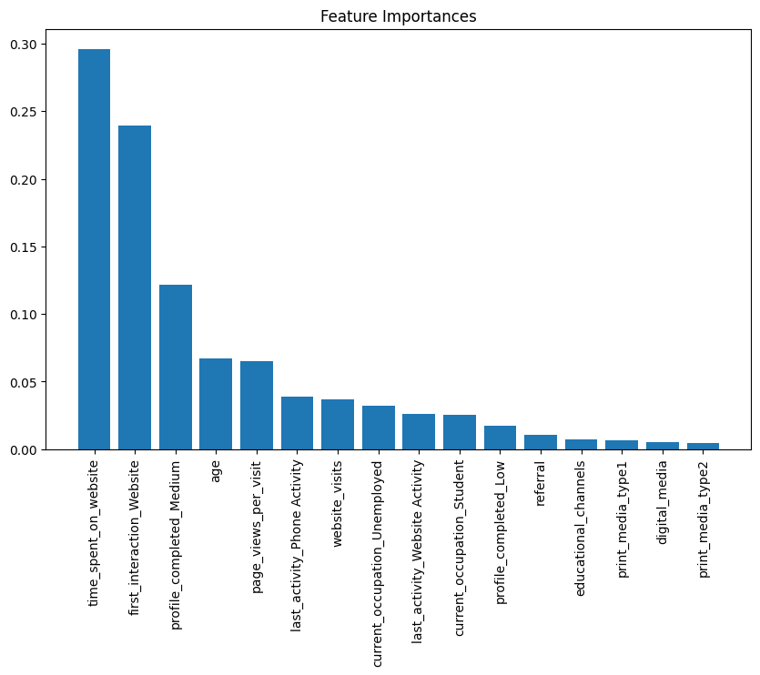

```python
# Step 1: Create the Random Forest model
model = RandomForestClassifier(random_state=42)

# Step 2: Fit the model to the training data
model.fit(X_train, y_train)

# Step 3: Make predictions on the test set
y_pred = model.predict(X_test)

# Step 4: Evaluate the model's performance (accuracy score)
accuracy = accuracy_score(y_test, y_pred)
print(f"Accuracy: {accuracy:.2f}")

# Step 5: Hyperparameter tuning using Grid Search
param_grid = {
    'n_estimators': [100, 200, 300],
    'max_depth': [None, 10, 20, 30],
    'min_samples_split': [2, 5, 10],
    'min_samples_leaf': [1, 2, 4],
    'criterion': ['gini', 'entropy']
}

# Step 6: Use GridSearchCV to find the best hyperparameters
grid_search = GridSearchCV(estimator=model, param_grid=param_grid, cv=5, scoring='accuracy', n_jobs=-1)
grid_search.fit(X_train, y_train)

# Step 7: Display the best hyperparameters
print("Best hyperparameters found by Grid Search:", grid_search.best_params_)

# Evaluate the best model on the test set
best_model = grid_search.best_estimator_
y_pred_best = best_model.predict(X_test)
accuracy_best = accuracy_score(y_test, y_pred_best)
print(f"Test set accuracy (with best model): {accuracy_best:.2f}")

# Step 8: Print the classification report
print("Classification Report:")
print(classification_report(y_test, y_pred))

# Step 9: Confusion Matrix
print("Confusion Matrix:")
print(confusion_matrix(y_test, y_pred))

# Step 10: Visualize the feature importance
importances = best_model.feature_importances_
indices = sorted(range(len(importances)), key=lambda k: importances[k], reverse=True)

# Step 11: Plotting the feature importances
plt.figure(figsize=(10, 6))
plt.title("Feature Importances")
plt.bar(range(X.shape[1]), importances[indices], align="center")
plt.xticks(range(X.shape[1]), X.columns[indices], rotation=90)
plt.show()
```

```python
# Make predictions on the training set using the best model
y_train_pred = best_model.predict(X_train)
# Calculate the accuracy by comparing the predicted values with the true values for the training set
accuracy_train = accuracy_score(y_train, y_train_pred)
# Print the accuracy of the best model on the training data, formatted to two decimal places
print(f"Train set accuracy: {accuracy_train:.2f}")
```

```
Train set accuracy: 0.90
```

These steps demonstrate how **Grid Search** and **pruning** help optimize the **Random Forest model** by reducing overfitting, improving its ability to generalize to unseen data, and enhancing its overall performance.